# Coding Exercise Solution

# Tidyverse practice

We’ll what we did above, but now we are using functionality from some of the packages in the `tidyverse` and others.

We’ll load the `tidyverse` collection of packages. If you don’t have them installed, do so. This will likely install a lot of packages and take a while. We’ll also load the `skimr` package. Install as needed.

```r
library(dslabs)
library(tidyverse)
library(skimr)
```

*Note that while I’m only loading these packages here for didactic reasons, it is generally best to have all `library` commands at the beginning of a document, this way a user can quickly see which ones to install. That prevents someone running a long simulation, only to get an error message at the end because a package to produce the final plot is missing.*

```r
dplyr::glimpse(gapminder)
```

```
## Rows: 10,545
## Columns: 9
## $ country          <fct> "Albania", "Algeria", "Angola", "Antigua and Barbuda"~
## $ year             <int> 1960, 1960, 1960, 1960, 1960, 1960, 1960, 1960, 1960,~
## $ infant_mortality <dbl> 115.40, 148.20, 208.00, NA, 59.87, NA, NA, 20.30, 37.~
## $ life_expectancy  <dbl> 62.87, 47.50, 35.98, 62.97, 65.39, 66.86, 65.66, 70.8~
## $ fertility        <dbl> 6.19, 7.65, 7.32, 4.43, 3.11, 4.55, 4.82, 3.45, 2.70,~
## $ population       <dbl> 1636054, 11124892, 5270844, 54681, 20619075, 1867396,~
## $ gdp              <dbl> NA, 13828152297, NA, NA, 108322326649, NA, NA, 966778~
## $ continent        <fct> Europe, Africa, Africa, Americas, Americas, Asia, Ame~
## $ region           <fct> Southern Europe, Northern Africa, Middle Africa, Cari~
```

```r
skimr::skim(gapminder)
```

Data summary

| Name | gapminder |
| --- | --- |
| Number of rows | 10545 |
| Number of columns | 9 |
| _______________________ |  |
| Column type frequency: |  |
| factor | 3 |
| numeric | 6 |
| ________________________ |  |
| Group variables | None |

**Variable type: factor**

| skim_variable | n_missing | complete_rate | ordered | n_unique | top_counts |
| --- | --- | --- | --- | --- | --- |
| country | 0 | 1 | FALSE | 185 | Alb: 57, Alg: 57, Ang: 57, Ant: 57 |
| continent | 0 | 1 | FALSE | 5 | Afr: 2907, Asi: 2679, Eur: 2223, Ame: 2052 |
| region | 0 | 1 | FALSE | 22 | Wes: 1026, Eas: 912, Wes: 912, Car: 741 |

**Variable type: numeric**

| skim_variable | n_missing | complete_rate | mean | sd | p0 | p25 | p50 | p75 | p100 | hist |
| --- | --- | --- | --- | --- | --- | --- | --- | --- | --- | --- |
| year | 0 | 1.00 | 1.988000e+03 | 1.645000e+01 | 1960.00 | 1974.0 | 1.988000e+03 | 2.002000e+03 | 2.016000e+03 | ▇▇▇▇▇ |
| infant_mortality | 1453 | 0.86 | 5.531000e+01 | 4.773000e+01 | 1.50 | 16.0 | 4.150000e+01 | 8.510000e+01 | 2.769000e+02 | ▇▃▂▁▁ |
| life_expectancy | 0 | 1.00 | 6.481000e+01 | 1.067000e+01 | 13.20 | 57.5 | 6.754000e+01 | 7.300000e+01 | 8.390000e+01 | ▁▁▃▇▇ |
| fertility | 187 | 0.98 | 4.080000e+00 | 2.030000e+00 | 0.84 | 2.2 | 3.750000e+00 | 6.000000e+00 | 9.220000e+00 | ▇▅▅▆▁ |
| population | 185 | 0.98 | 2.701461e+07 | 1.066649e+08 | 31238.00 | 1333486.0 | 5.009043e+06 | 1.523179e+07 | 1.376049e+09 | ▇▁▁▁▁ |
| gdp | 2972 | 0.72 | 1.479544e+11 | 6.979128e+11 | 40395127.89 | 1845780110.0 | 7.794215e+09 | 5.539965e+10 | 1.174422e+13 | ▇▁▁▁▁ |

Pull out african countries and only some of the variables.

```r
africasmall <- gapminder %>% dplyr::filter(continent == "Africa") %>% dplyr::select(life_expectancy,country,population,infant_mortality)
skim(africasmall)
```

Data summary

| Name | africasmall |
| --- | --- |
| Number of rows | 2907 |
| Number of columns | 4 |
| _______________________ |  |
| Column type frequency: |  |
| factor | 1 |
| numeric | 3 |
| ________________________ |  |
| Group variables | None |

**Variable type: factor**

| skim_variable | n_missing | complete_rate | ordered | n_unique | top_counts |
| --- | --- | --- | --- | --- | --- |
| country | 0 | 1 | FALSE | 51 | Alg: 57, Ang: 57, Ben: 57, Bot: 57 |

**Variable type: numeric**

| skim_variable | n_missing | complete_rate | mean | sd | p0 | p25 | p50 | p75 | p100 | hist |
| --- | --- | --- | --- | --- | --- | --- | --- | --- | --- | --- |
| life_expectancy | 0 | 1.00 | 54.38 | 8.97 | 13.2 | 48.23 | 53.98 | 60.1 | 77.6 | ▁▁▆▇▂ |
| population | 51 | 0.98 | 12235960.96 | 19267350.86 | 41538.0 | 1605232.50 | 5570981.50 | 13888152.2 | 182201962.0 | ▇▁▁▁▁ |
| infant_mortality | 226 | 0.92 | 95.12 | 43.87 | 11.4 | 62.20 | 93.40 | 124.7 | 237.4 | ▅▇▇▂▁ |

Note that I often write both the function name and the package where the function comes from, i.e. `dplyr::filter` instead of just `filter`. It is not strictly needed, but if multiple functions with the same name exist in different packages (which is for instance true for `filter`), being explicit about which one you want helps with potential problems in the code.

Plotting life expectancy as function of infant mortality and population, giving each country a separate color.

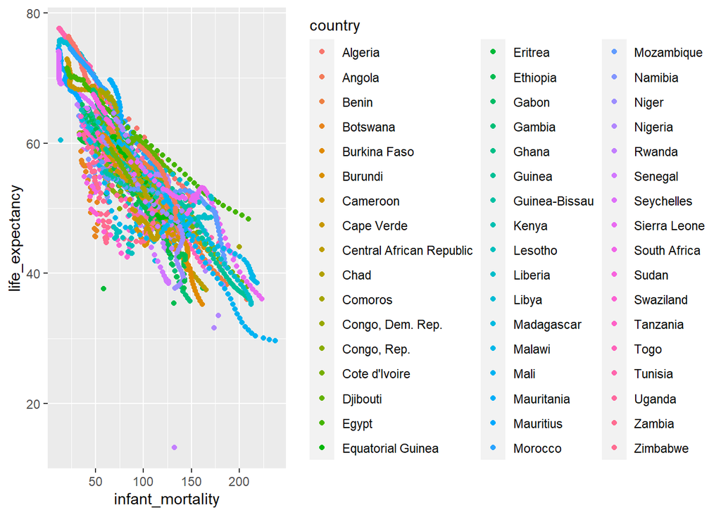

```r
p1 <- africasmall %>% ggplot(aes(x = infant_mortality, y = life_expectancy, color = country)) + geom_point()
plot(p1)
```

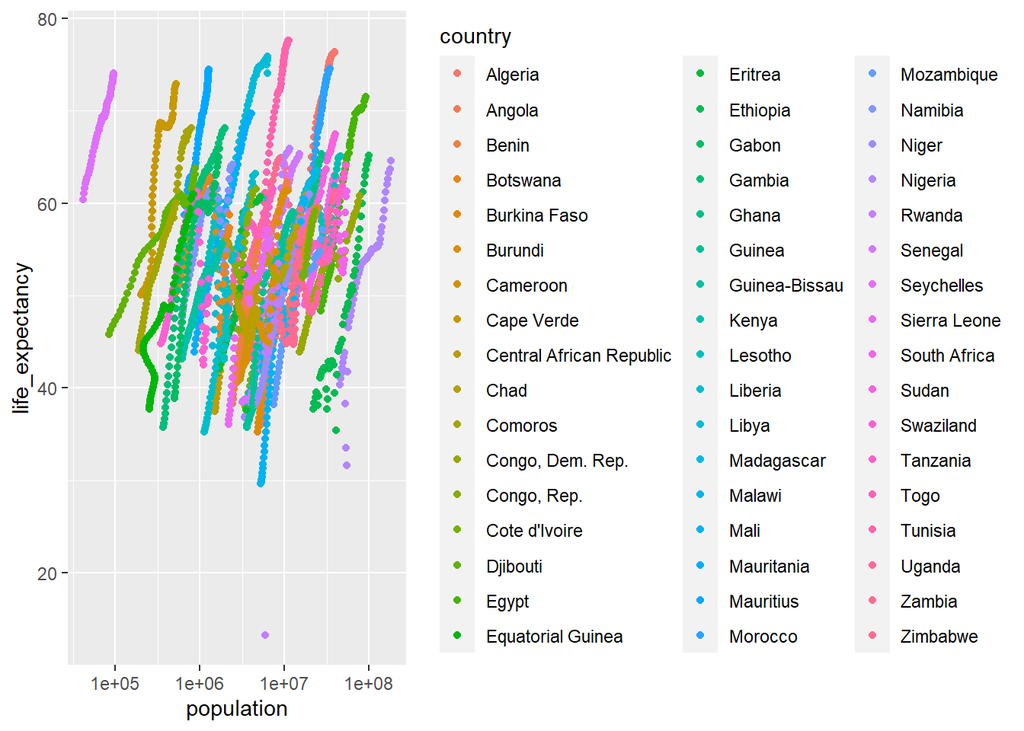

```r
p2 <- africasmall %>% ggplot(aes(x = population, y = life_expectancy, color = country )) + geom_point() + scale_x_log10()
plot(p2)
```

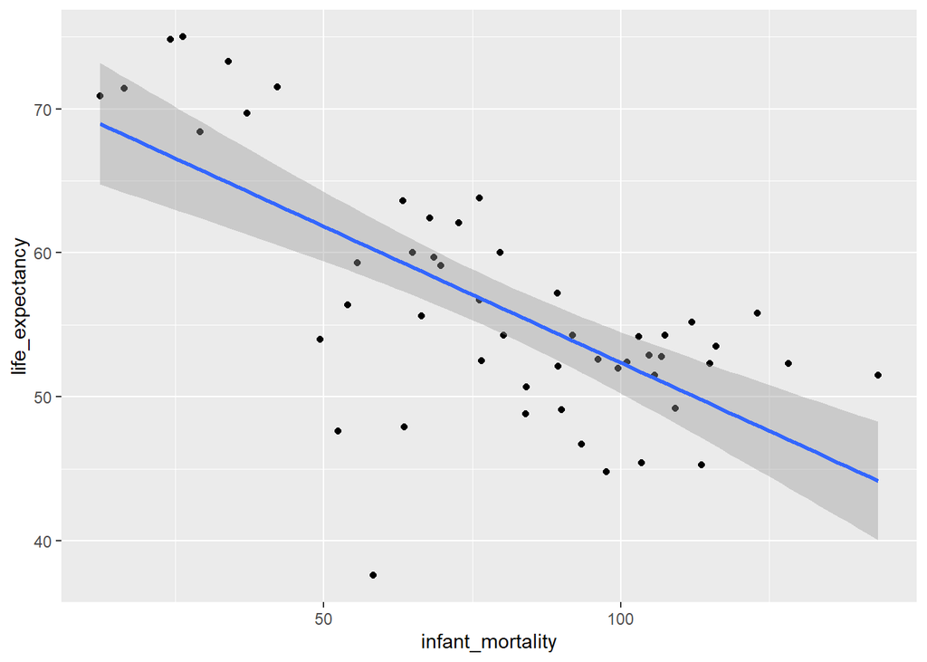

```r
gapminder %>% dplyr::filter(continent == "Africa", year == 2000) %>%
             ggplot(aes(x = infant_mortality, y = life_expectancy)) + geom_point() + geom_smooth(method = "lm") -> p3
plot(p3)
```